# Battle Creek

Sadie Gill, Mark Tompkins, Erin Cain

June 11, 2019

## Future Data Improvements

None Planned

## Instream Spawning and Rearing Habitat

**Data Source:**  
[Thomas R. Payne & Associates 1995](https://s3-us-west-2.amazonaws.com/cvpiahabitat-r-package/cvpia-sit-model-inputs/Payne1995_BattleCreekIFIM.pdf) (pg C-1)

Instream spawning and rearing habitat for Fall Run Chinook Salmon and Steelhead in Battle Creek is based on data from Thomas R. Payne & Associates instream flow evaluations conducted for the California Department of Fish and Wildlife. These evaluations developed relationships between flow and suitable spawning and rearing habitat for Battle Creek from seven study reaches in Battle Creek. The consolidated WUA for all mainstem reaches are provided in Appendix C page C-1. Mark Gard from the U.S. Fish and Wildlife Service provided the consolidated full-river data for the entire Battle Creek watershed in a spreadsheet (see ‘~/cvpiaHabitat/data-raw/mark_gard_data/IFIMWUA.xlsx’), and instructed us to use A1:E36 of the ‘Battle’ tab within his ‘IFIMWUA.xlsx’. We consolidated aditional Steelhead data from Thomas Payne and Associates 1995 in a spreadsheet (see’~cvpiaHabitat/data-raw/weighted_composite_battle.csv).

### Combine Spawning and Rearing Data

The instream spawning and rearing habitat data described above for Fall Run Chinook Salmon (FR) and Steelhead (ST) is combined for use in the DSM in the following format. Units are in square feet per 1000 feet.

| flow_cfs | FR_spawn_wua | FR_fry_wua | FR_juv_wua | ST_adult_wua | ST_spawn_wua | ST_fry_wua | ST_juv_wua | watershed |
| --- | --- | --- | --- | --- | --- | --- | --- | --- |
| 8 | 130.33 | 15577.42 | 4951.72 | 9122.98 | 266.30 | 4612.27 | 13056.70 | Battle Creek |
| 10 | 200.10 | 15410.91 | 5858.00 | 9728.00 | 364.83 | 4289.54 | 13667.70 | Battle Creek |
| 12 | 275.77 | 15181.16 | 6704.73 | 10253.11 | 458.80 | 4035.90 | 14128.02 | Battle Creek |
| 14 | 358.81 | 14928.81 | 7488.45 | 10711.28 | 565.26 | 3809.16 | 14464.77 | Battle Creek |
| 16 | 435.23 | 14661.05 | 8211.50 | 11113.88 | 680.82 | 3588.96 | 14722.92 | Battle Creek |

*…with 35 more rows.*

### Spawning WUA

The instream spawning habitat weighted usable areas for Fall Run Chinook Salmon and Steelhead in Battle Creek.

#### Fall Run Chinook Salmon Spawning WUA Plot

The following plot shows the weighted usable spawning area in square feet per thousand feet of river for Fall Run Chinook Salmon. These area per length rates are multiplied by the total spawning reach length mapped by the SIT.

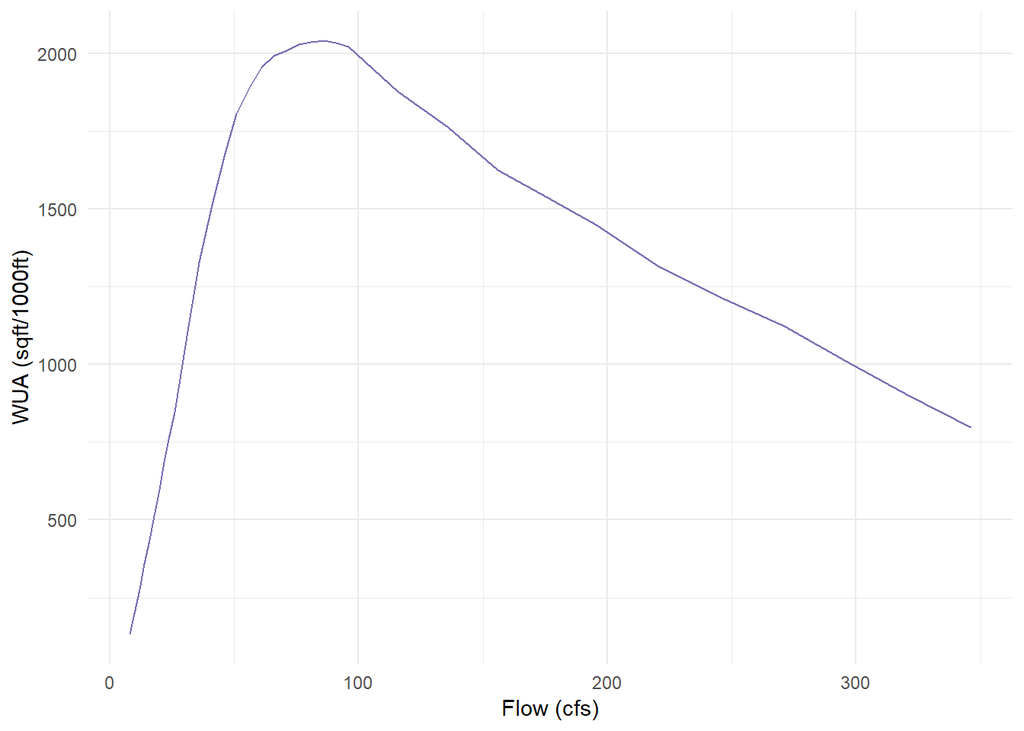

#### Steelhead Spawning WUA Plot

The following plot shows the weighted usable spawning area in square feet per thousand feet of river for Steelhead. These area per length rates are multiplied by the total spawning reach length mapped by the SIT.

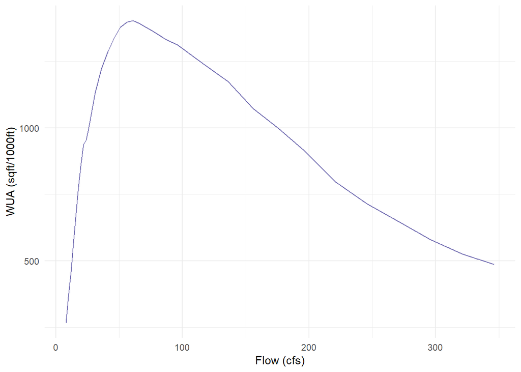

### Rearing WUA

The fry and juvenile instream rearing habitat weighted usable areas for Fall Run Chinook Salmon and Steelhead in Battle Creek.

#### Fall Run Chinook Salmon Rearing WUA Plot

The following plot shows the weighted usable rearing area in square feet per thousand feet of river for Fall Run Chinook Salmon fry and juvenile. These rates are multiplied by the total rearing reach length mapped by the SIT.

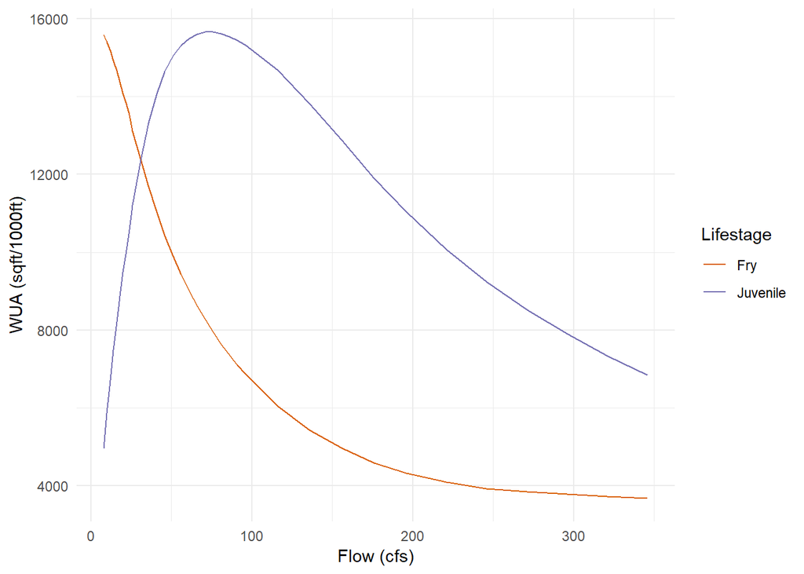

#### Rearing WUA Plot

The following plot shows the weighted usable rearing area in square feet per thousand feet of river for Steelhead fry and juvenile. These rates are multiplied by the total rearing reach length mapped by the SIT.

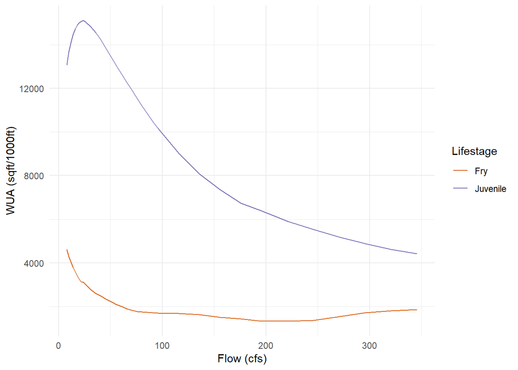